# Analyse statistique des données avec R

# 1 Présentation et manipulation des données

Dans ce tutoriel, on va travailler avec le jeu de données tiré de l’enquête **General Social Survey (GSS)** sur le bonheur inclus dans l’extension `questionr`.

*GSS est une enquête annuelle transversale sur les Américains, menée depuis 1972*

## 1.1 Chargement de données

On commence donc par charger l’extension `questionr` et le jeu de données par la suite :

```r
library(tidyverse)
#install.package("questionr")
library(questionr)

data(happy) #pour charger le jeu de données

d <- happy #pour renommer le jeu de données
```

Pour comprendre la structure du notre base de données, on peut utiliser la fonction `str()` :

```r
str(d)
```

```
## 'data.frame':    51020 obs. of  10 variables:
##  $ id     : num  1 2 3 4 5 6 7 8 9 10 ...
##  $ happy  : Factor w/ 3 levels "not too happy",..: 1 1 2 1 2 2 1 1 2 2 ...
##  $ year   : num  1972 1972 1972 1972 1972 ...
##  $ age    : num  23 70 48 27 61 26 28 27 21 30 ...
##  $ sex    : Factor w/ 2 levels "male","female": 2 1 2 2 2 1 1 1 2 2 ...
##  $ marital: Factor w/ 5 levels "married","never married",..: 2 1 1 1 1 2 3 2 2 1 ...
##  $ degree : Factor w/ 5 levels "lt high school",..: 4 1 2 4 2 2 2 4 2 2 ...
##  $ finrela: Factor w/ 5 levels "far below average",..: 3 4 3 3 4 4 4 3 3 2 ...
##  $ health : Factor w/ 4 levels "poor","fair",..: 3 2 4 3 3 3 4 3 4 2 ...
##  $ wtssall: num  0.445 0.889 0.889 0.889 0.889 ...
```

Le jeu de données est composé de *51 020* observations et *10* variables, qui sont décrites comme suit :

- **happy** : niveau du bonheur (*very happy, pretty happy, not too happy*).
- **year** : année de l’enquête.
- **age** : âge en années.
- **sexe** : sexe (*female, male*).
- **marital** : état civil (*married, never married, divorced, widowed, separated*).
- **degree** : niveau d’éducation (*lt high school, high school, junior college, bachelor, graduate*).
- **finrela** : situation financière relative (__far above, above average, average, below average, far below_).
- **health** : niveau de santé (*excellent, good, fair, poor*)
- **wtssall** : poids de probabilité.

## 1.2 Renommer les colonnes :

On peut renommer les colonnes de la base de données en utilisant la fonction `rename()` de `dplyr`

```r
d <-rename(d,
           niv_bonheur = happy,
           etat_matrimonial = marital,
           niv_education = degree,
           sit_financiere = finrela,
           niv_sante = health,
           sexe = sex,
           poids_prob = wtssall)

colnames(d)
```

```
##  [1] "id"               "niv_bonheur"      "year"             "age"
##  [5] "sexe"             "etat_matrimonial" "niv_education"    "sit_financiere"
##  [9] "niv_sante"        "poids_prob"
```

## 1.3 Ajouter une colonne :

On veut ajouter une colonne nommée “niv_bonheur_fr”, qui reprend les même facteurs de la variable “niv_bonheur” mais qui sont traduits en français cette fois (*Ex. “très heureux” à la place de “very happy”*). Pour ce faire, on va utiliser la fonction mutate() pour ajouter la colonne et la fonction `fct_recode()` du package `forecats` qui permet de manipuler les niveaux d’une variable factorielle :

```r
#install.packages("forcats")
library(forcats)
#help(fct_recode)
d <- d %>% mutate(niv_bonheur_fr = fct_recode(niv_bonheur,
                                              "très heureux" = "very happy",
                                              "assez heureux" = "pretty happy",
                                              "pas trop heureux" = "not too happy"))

tab <- table(d$niv_bonheur_fr) ## Tri à plat pour vérifier les nouveaux facteurs

library(kableExtra)
kable(tab) ## pour une meilleure visualisation
```

| Var1 | Freq |
| --- | --- |
| pas trop heureux | 5629 |
| assez heureux | 25874 |
| très heureux | 14800 |

Une méthode alternative en utilisant la fonction `ifelse()` :

```
help(ifelse)
d$niv_bonheur_fr <- NA ## pour créer une nouvelle colonne
d$niv_bonheur_fr <- ifelse(d$niv_bonheur == "very happy", "très heureux",
                        ifelse(d$niv_bonheur == "pretty happy", "assez heureux",
                               ifelse(d$niv_bonheur == "not too happy", "pas trop heureux", d$niv_bonheur_fr
                                      )))
```

## 1.4 Exercices :

- Faites de même pour la variable “etat_matrimonial”;
- Sélectionner les personnes “très heureux”, qui sont mariées (*married*) et ayant une situation financière largement au-dessus de la moyenne (*“far above”*)

## 1.5 Sélectionner des observations

On cherche ici à sélectionner un sous-échantillon de **6 000** sujets parmi les **51 000** qui sont présents dans la base de données.

Pour ce faire, on applique la fonction `sample_n()` du package `dplyr` qui permet de tirer aléatoirement des lignes de la base de données, sans remplacement (`replace = FALSE`) :

```r
set.seed(123)
d <- sample_n(d, size = 6000, replace = FALSE)

dim(d) ## pour afficher la dimension de la bd
```

```
## [1] 6000   11
```

# 2 Analyse descriptive :

## 2.1 Variables quantitatives :

La fonction `describe()` du package `psych` permet de fournir des statistiques descriptives sur les variables quantitatives :

```r
library(psych)
tab <- psych::describe(d[, c("age", "poids_prob")])
kable(tab)
```

|  | vars | n | mean | sd | median | trimmed | mad | min | max | range | skew | kurtosis | se |
| --- | --- | --- | --- | --- | --- | --- | --- | --- | --- | --- | --- | --- | --- |
| age | 1 | 5972 | 45.3670462 | 17.4326536 | 42.0000 | 44.281708 | 19.2738000 | 18.0000 | 89.0000 | 71.0000 | 0.4608857 | -0.7698096 | 0.2255816 |
| poids_prob | 2 | 6000 | 0.9995762 | 0.4359385 | 1.0116 | 0.948119 | 0.1688681 | 0.4297 | 5.7288 | 5.2991 | 1.5469209 | 5.8757925 | 0.0056279 |

## 2.2 Variables qualitatives :

### 2.2.1 Tri à plat

Pour représenter la répartition des valeurs d’une variable qualitative, on peut utiliser la fonction `freq()` du package `questionr` :

```r
library(questionr)
freq(d$niv_bonheur)
```

```
##                  n    % val%
## not too happy  654 10.9 12.0
## pretty happy  3052 50.9 55.9
## very happy    1755 29.2 32.1
## NA             539  9.0   NA
```

```r
freq(d$etat_matrimonial)
```

```
##                  n    % val%
## married       3233 53.9 53.9
## never married 1197 20.0 20.0
## divorced       775 12.9 12.9
## widowed        578  9.6  9.6
## separated      215  3.6  3.6
## NA               2  0.0   NA
```

```r
# freq(d$niv_education)
# freq(d$niv_sante)
# freq(d$sit_financiere)
# freq(d$sexe)
```

On peut éviter les appels multiples de la même fonction grâce à la fonction `lapply()`, qui permet d’appliquer une fonction de façon itérative

```r
vars_qual <- c("niv_bonheur", "etat_matrimonial", "niv_education", "niv_sante", "sit_financiere", "sexe") ## pour sélectionner les vars qualitatives de la BD

tab <- lapply(d[, vars_qual], freq)
kable(tab)
```

|  | n | % | val% |
| --- | --- | --- | --- |
| not too happy | 654 | 10.9 | 12.0 |
| pretty happy | 3052 | 50.9 | 55.9 |
| very happy | 1755 | 29.2 | 32.1 |
| NA | 539 | 9.0 | NA |

|  | n | % | val% |
| --- | --- | --- | --- |
| married | 3233 | 53.9 | 53.9 |
| never married | 1197 | 20.0 | 20.0 |
| divorced | 775 | 12.9 | 12.9 |
| widowed | 578 | 9.6 | 9.6 |
| separated | 215 | 3.6 | 3.6 |
| NA | 2 | 0.0 | NA |

|  | n | % | val% |
| --- | --- | --- | --- |
| lt high school | 1370 | 22.8 | 22.9 |
| high school | 3138 | 52.3 | 52.4 |
| junior college | 311 | 5.2 | 5.2 |
| bachelor | 790 | 13.2 | 13.2 |
| graduate | 374 | 6.2 | 6.3 |
| NA | 17 | 0.3 | NA |

|  | n | % | val% |
| --- | --- | --- | --- |
| poor | 256 | 4.3 | 5.7 |
| fair | 828 | 13.8 | 18.3 |
| good | 2021 | 33.7 | 44.7 |
| excellent | 1417 | 23.6 | 31.3 |
| NA | 1478 | 24.6 | NA |

|  | n | % | val% |
| --- | --- | --- | --- |
| far below average | 304 | 5.1 | 5.6 |
| below average | 1241 | 20.7 | 22.8 |
| average | 2766 | 46.1 | 50.8 |
| above average | 1032 | 17.2 | 19.0 |
| far above average | 101 | 1.7 | 1.9 |
| NA | 556 | 9.3 | NA |

|  | n | % | val% |
| --- | --- | --- | --- |
| male | 2642 | 44 | 44 |
| female | 3358 | 56 | 56 |

### 2.2.2 Croisement des variables qualitatives

Pour faire un tableau croisé entre deux variables qualitatives, on utilise comme pour un tri à plat la fonction `table()` mais à laquelle on passe cette fois deux variables en argument.

Par exemple, si on veut croiser le niveau du bonheur avec le sexe des enquêtés :

```r
tab_sexe <- table(d$niv_bonheur, d$sexe)
kable(tab_sexe)
```

|  | male | female |
| --- | --- | --- |
| not too happy | 283 | 371 |
| pretty happy | 1379 | 1673 |
| very happy | 751 | 1004 |

Pour avoir un tableau en pourcentage, on peut utiliser les deux fonctions `lprop` (pour les pourcentages ligne) et `cprop` (pour les pourcentages colonne) :

```r
tab_sexe <- table(d$niv_bonheur, d$sexe)
tab1 <- lprop(tab_sexe)
kable(tab1)
```

|  | male | female | Total |
| --- | --- | --- | --- |
| not too happy | 43.27217 | 56.72783 | 100 |
| pretty happy | 45.18349 | 54.81651 | 100 |
| very happy | 42.79202 | 57.20798 | 100 |
| All | 44.18605 | 55.81395 | 100 |

```r
tab2 <- cprop(tab_sexe)
kable(tab2)
```

|  | male | female | All |
| --- | --- | --- | --- |
| not too happy | 11.72814 | 12.17192 | 11.97583 |
| pretty happy | 57.14878 | 54.88845 | 55.88720 |
| very happy | 31.12308 | 32.93963 | 32.13697 |
| Total | 100.00000 | 100.00000 | 100.00000 |

- **Croisement “niv_bonheur” et “etat_matrimonial” :**

```r
tab_EM <- table(d$niv_bonheur, d$etat_matrimonial)
kable(cprop(tab_EM))
```

|  | married | never married | divorced | widowed | separated | All |
| --- | --- | --- | --- | --- | --- | --- |
| not too happy | 7.640525 | 14.74654 | 17.20117 | 17.23485 | 30.52632 | 11.97802 |
| pretty happy | 51.935375 | 63.22581 | 60.78717 | 58.33333 | 51.05263 | 55.87912 |
| very happy | 40.424100 | 22.02765 | 22.01166 | 24.43182 | 18.42105 | 32.14286 |
| Total | 100.000000 | 100.00000 | 100.00000 | 100.00000 | 100.00000 | 100.00000 |

```r
tab_edu <- table(d$niv_bonheur, d$niv_education)
kable(cprop(tab_edu))
```

|  | lt high school | high school | junior college | bachelor | graduate | All |
| --- | --- | --- | --- | --- | --- | --- |
| not too happy | 18.18182 | 11.00141 | 10.46931 | 7.746479 | 6.153846 | 11.97209 |
| pretty happy | 52.15716 | 58.18054 | 56.31769 | 54.225352 | 53.846154 | 55.87587 |
| very happy | 29.66102 | 30.81805 | 33.21300 | 38.028169 | 40.000000 | 32.15204 |
| Total | 100.00000 | 100.00000 | 100.00000 | 100.000000 | 100.000000 | 100.00000 |

- **Croisement “niv_bonheur” et “sit_financiere” :**

```r
tab_SF <- table(d$niv_bonheur, d$sit_financiere)
kable(cprop(tab_SF))
```

|  | far below average | below average | average | above average | far above average | All |
| --- | --- | --- | --- | --- | --- | --- |
| not too happy | 30.10033 | 17.33116 | 9.444243 | 6.933594 | 11 | 11.93340 |
| pretty happy | 48.49498 | 59.72335 | 56.992372 | 52.148438 | 43 | 55.96670 |
| very happy | 21.40468 | 22.94548 | 33.563385 | 40.917969 | 46 | 32.09991 |
| Total | 100.00000 | 100.00000 | 100.000000 | 100.000000 | 100 | 100.00000 |

- **Croisement “niv_bonheur” et “niv_sante” :**

```r
tab_Sante <- table(d$niv_bonheur, d$niv_sante)
kable(cprop(tab_Sante))
```

|  | poor | fair | good | excellent | All |
| --- | --- | --- | --- | --- | --- |
| not too happy | 34.05172 | 21.06632 | 10.77006 | 6.867924 | 12.71814 |
| pretty happy | 45.68966 | 55.00650 | 60.85083 | 48.075472 | 54.88884 |
| very happy | 20.25862 | 23.92718 | 28.37911 | 45.056604 | 32.39302 |
| Total | 100.00000 | 100.00000 | 100.00000 | 100.000000 | 100.00000 |

### 2.2.3 Test d’indépendance du $\chi^2$

On peut compléter les tableaux croisés par un test d’indépendance du $\chi^2$, qui permet de tester l’hypothèse d’indépendance entre deux variables catégorielles.

Pour effectuer un test de ce type, on applique la fonction `chisq.test()` au tableu croisé calculé précédemment :

```r
chisq.test(tab_sexe)
```

```
##
##  Pearson's Chi-squared test
##
## data:  tab_sexe
## X-squared = 2.8356, df = 2, p-value = 0.2422
```

```r
chisq.test(tab_EM)
```

```
##
##  Pearson's Chi-squared test
##
## data:  tab_EM
## X-squared = 299.78, df = 8, p-value < 2.2e-16
```

```r
chisq.test(tab_edu)
```

```
##
##  Pearson's Chi-squared test
##
## data:  tab_edu
## X-squared = 88.867, df = 8, p-value = 7.898e-16
```

```r
chisq.test(tab_SF)
```

```
##
##  Pearson's Chi-squared test
##
## data:  tab_SF
## X-squared = 236.19, df = 8, p-value < 2.2e-16
```

```r
chisq.test(tab_Sante)
```

```
##
##  Pearson's Chi-squared test
##
## data:  tab_Sante
## X-squared = 295.56, df = 6, p-value < 2.2e-16
```

Le résultat du test, sur chaque tableau croisé, nous indique trois valeurs :

- `X-square` : la valeur de la statistique du $\chi^2$.
- `df` : le nombre de degrés de libertés du test.
- `p` : le fameux p-value, qui indique la probabilité d’obtenir une valeur de la statistique du $\chi^2$ au moins aussi extrême sous l’hypothèse d’indépendance.

### 2.2.4 Représentation graphique

Il est possible de faire une représentation graphique d’un tableau croisé, par exemple avec la fonction `mosaicplot()` :

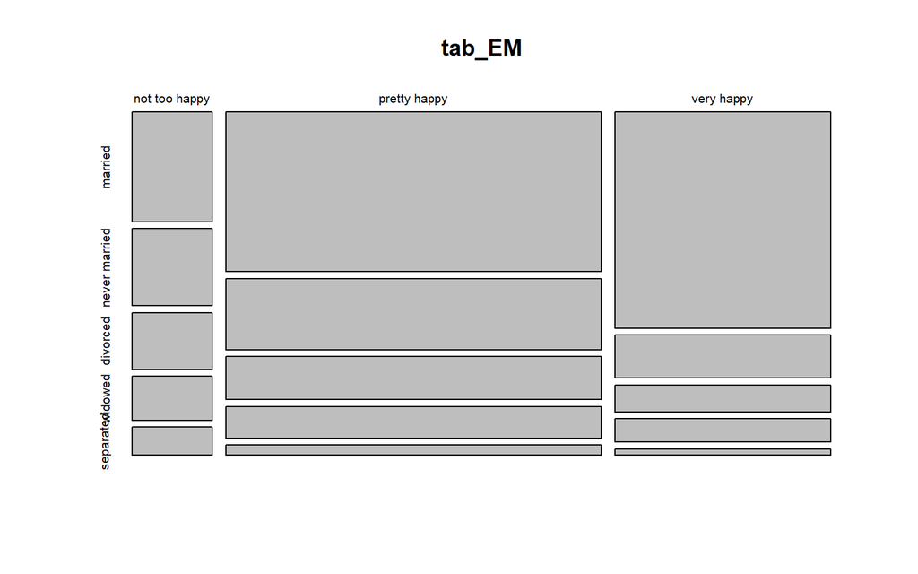

```r
mosaicplot(tab_EM)
```

On peut améliorer ce graphique en colorant les cases selon les résidus du test du $\chi^2$ (argument `shade = TRUE`) :

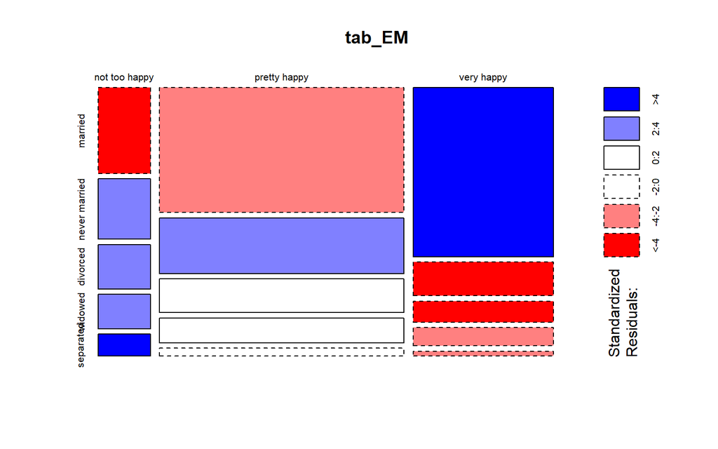

```r
mosaicplot(tab_EM, shade = TRUE)
```

## 2.3 Croisement d’une variable quantitative et d’une variable qualitative

### 2.3.1 Représentation graphique

Pour analyser la répartition de l’âge selon la catégorie d’appartenance de la variable qualitative “niv_bonheur”, on peut commencer par une représentation graphique de type “boîte à moustache” à l’aide de la fonction `boxplot()` :

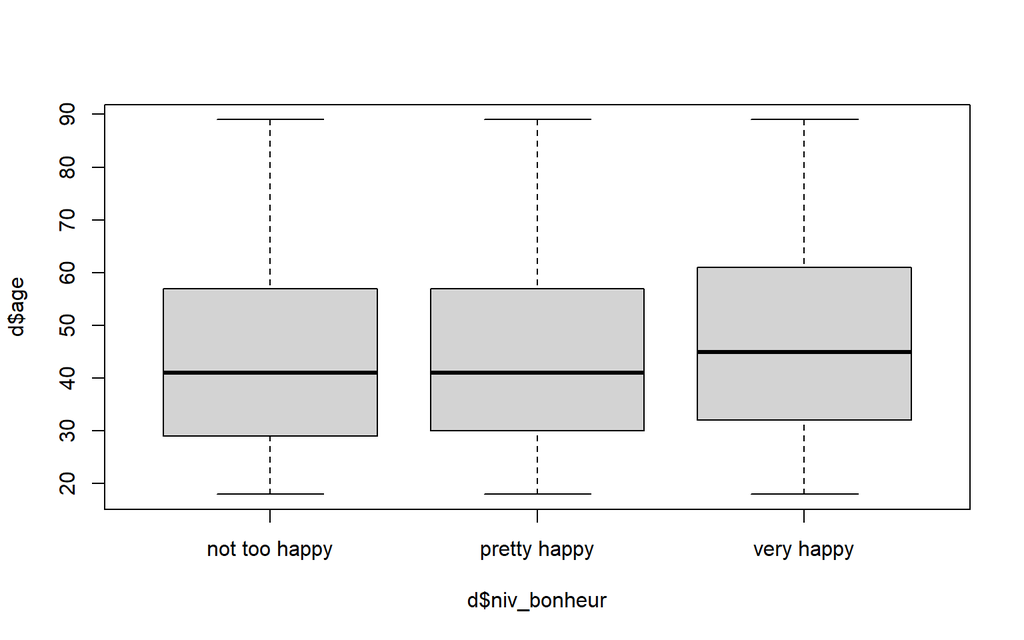

```r
boxplot(d$age ~ d$niv_bonheur)
```

## 2.4 Calcul d’indicateurs

Pour calculer l’âge moyen par niveau du bonheur, on peut travailler avec les “verbs” de `dplyr` :

```r
d %>%
  group_by(niv_bonheur) %>%
  summarise(Moyenne = mean(age, na.rm = TRUE))
```

```
## # A tibble: 4 x 2
##   niv_bonheur   Moyenne
##   <fct>           <dbl>
## 1 not too happy    44.0
## 2 pretty happy     44.6
## 3 very happy       47.0
## 4 <NA>             46.0
```

On peut également ajouter les écart-types :

```r
tab_ind <- d %>%
  group_by(niv_bonheur) %>%
  summarise(Moyenne = mean(age, na.rm = TRUE),
            ET = sd(age, na.rm = TRUE))

kable(tab_ind)
```

| niv_bonheur | Moyenne | ET |
| --- | --- | --- |
| not too happy | 44.04160 | 17.72483 |
| pretty happy | 44.61566 | 17.35943 |
| very happy | 46.97198 | 17.60278 |
| NA | 45.99626 | 16.55113 |

## 2.5 Tests statistiques

Pour comparer les moyennes des âges par sexe, on peut utiliser le test *t du Student*.

Un test *t* s’effectue à l’aide de la fonction `t.test()`. Ainsi, on peut tester l’hypthèse d’égalité des âges moyens selon le sexe :

```r
t.test(d$age ~ d$sexe)
```

```
##
##  Welch Two Sample t-test
##
## data:  d$age by d$sexe
## t = -2.7371, df = 5768.7, p-value = 0.006218
## alternative hypothesis: true difference in means is not equal to 0
## 95 percent confidence interval:
##  -2.1204637 -0.3506088
## sample estimates:
##   mean in group male mean in group female
##             44.67666             45.91220
```

Le résultat du test est significatif, on rejette l’hypothèse nulle d’égalité des moyennes des âges entre les hommes et les femmes.

==> Le test *t* s’applique à des distributions normales. On doit donc vérifier avant si la distribution des âges est normale !!

On peut se faire un premier aperçu visuel pour vérifier la normalité de la distribution de l’âge dans les deux groupes

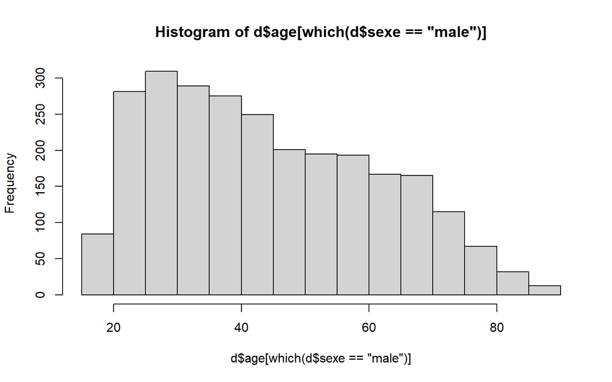

```r
hist(d$age[which(d$sexe == "male")])
```

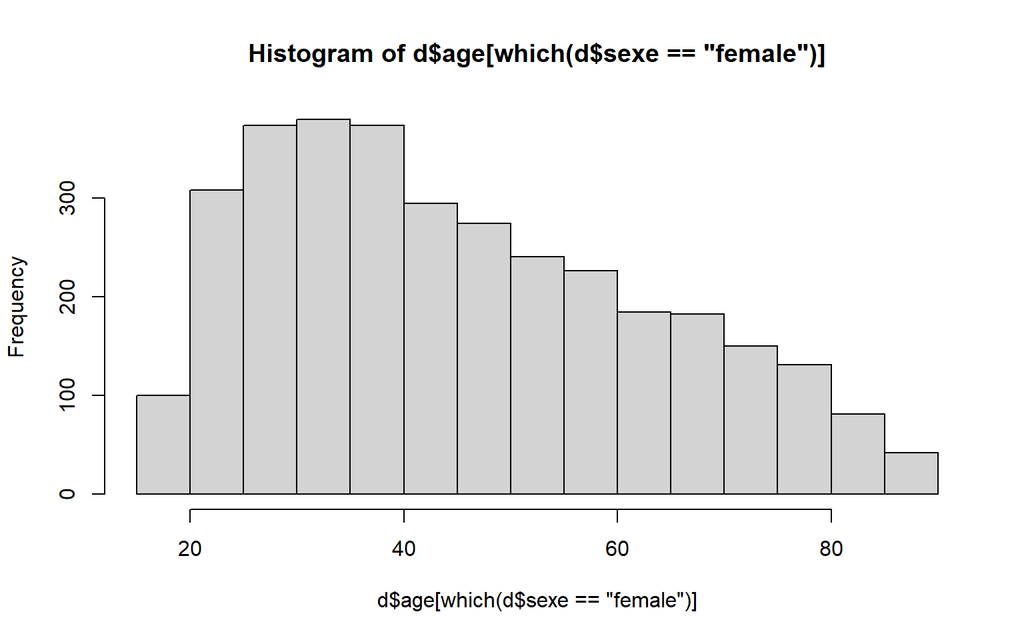

```r
hist(d$age[which(d$sexe == "female")])
```

Les deux distributions ne semblent pas proches d’une distribution normale.

On peut également tester cette normalité en faisant appel au test de *Shapiro-Wilk*, par la fonction `shapiro.test` :

```r
shapiro.test(d$age[which(d$sexe == "male")])
```

```
##
##  Shapiro-Wilk normality test
##
## data:  d$age[which(d$sexe == "male")]
## W = 0.95661, p-value < 2.2e-16
```

```r
shapiro.test(d$age[which(d$sexe == "female")])
```

```
##
##  Shapiro-Wilk normality test
##
## data:  d$age[which(d$sexe == "female")]
## W = 0.95326, p-value < 2.2e-16
```

Le test est significatif dans les deux cas, et l’hypothèse de normalité est rejetée par la suite.

Dans ce cas, on peut travailler par un test non-paramétrique (qui ne fait pas d’hypothèses sur les lois de distribution) pour comparer les deux groupes, en l’occurrence le test des rangs de *Wilcoxon*, à l’aide de la fonction `wilcox.test()` :

```r
wilcox.test(d$age ~ d$sexe)
```

```
##
##  Wilcoxon rank sum test with continuity correction
##
## data:  d$age by d$sexe
## W = 4248279, p-value = 0.02504
## alternative hypothesis: true location shift is not equal to 0
```

la p-value est à nouveau inférieur au seuil de 5%, on rejette l’hypothèse d’égalité des moyennes d’âges entre les hommes et les femmes.

## 2.6 Exercices :

- Faire le boxplot qui croise l’âge avec le niveau de santé, et calculer l’âge moyen par catégorie de `niv_sante`.
- Tester l’hypothèse d’égalité des âges moyens entre les catégories du niveau de santé.
- Effectuez les mêmes analyses sur les autres variables : `niv_education`, `sit_financiere` et `etat_matrimonial.`

# 3 Modélisation

## 3.1 Régression logistique ordinale

Puisque notre variable d’intérêt (variable dépendante : `niv_bonheur`) est nominale ordonnée (il existe un ordre explicite dans les catégories), la régression logistique à probabilités proportionnelles (**Proportional Odds Logistic Regression**) est la plus adaptée dans ce cas.

Pour estimer un modèle de régression logistique ordinale, on utilise la fonction `polr()` du package `MASS`. Mais avant cela, on commence d’abord par changer les modalités de référence des variables factorielles en utilisant la fonction `relevel()`. En fait, R choisit par défaut la première modalité comme référence, alors que pour avoir des meilleures interprétations on est obligé de changer la référence (*par exemple quand la variable est ordonnée on préfère choisir comme modalité de référence une modalité plutôt centrale*) :

```r
# Changer les ref
d$niv_education <- relevel(d$niv_education, ref = "junior college") ## la modalité centrale comme réf
d$etat_matrimonial <- relevel(d$etat_matrimonial, ref = "married") ## on choisit ici la catégorie marié(e) comme réf
d$sit_financiere <- relevel(d$sit_financiere, ref = "average") ## la modalité centrale comme réf
d$niv_sante <- relevel(d$niv_sante, ref = "fair") ## la modalité centrale comme réf

# d_train & d_test
index <- sample(1:6000, 4000)
d_train <- d[index,]
d_test <- d[-index,]


library(MASS)

reg_model <- polr(niv_bonheur ~ age + niv_education + etat_matrimonial + sit_financiere + niv_sante, data = d_train)
summary(reg_model)
```

```
## Call:
## polr(formula = niv_bonheur ~ age + niv_education + etat_matrimonial +
##     sit_financiere + niv_sante, data = d_train)
##
## Coefficients:
##                                    Value Std. Error t value
## age                              0.01999    0.00280  7.1405
## niv_educationlt high school     -0.07998    0.18863 -0.4240
## niv_educationhigh school        -0.01025    0.17293 -0.0593
## niv_educationbachelor            0.11990    0.19745  0.6073
## niv_educationgraduate            0.24293    0.22236  1.0925
## etat_matrimonialnever married   -0.58683    0.10635 -5.5180
## etat_matrimonialdivorced        -0.85351    0.12206 -6.9926
## etat_matrimonialwidowed         -1.03657    0.15269 -6.7885
## etat_matrimonialseparated       -1.07302    0.22049 -4.8666
## sit_financierefar below average -0.71132    0.18184 -3.9119
## sit_financierebelow average     -0.25541    0.09862 -2.5899
## sit_financiereabove average      0.20366    0.10512  1.9374
## sit_financierefar above average  0.25174    0.30681  0.8205
## niv_santepoor                   -0.49652    0.19491 -2.5474
## niv_santegood                    0.53061    0.11115  4.7740
## niv_santeexcellent               1.18386    0.12171  9.7269
##
## Intercepts:
##                            Value   Std. Error t value
## not too happy|pretty happy -1.0726  0.2355    -4.5552
## pretty happy|very happy     1.9246  0.2372     8.1145
##
## Residual Deviance: 4831.805
## AIC: 4867.805
## (1262 observations deleted due to missingness)
```

Dans la sortie ci-dessus, on obtient les informations suivantes :

- L’équation du modèle
- Les coefficients de régression avec leurs valeurs, les erreurs standard et la valeur t. Il n’y a pas de test de signification par défaut mais nous pouvons calculer la valeur p en comparant la valeur t à la distribution normale standard.
- Les estimations pour deux intercepts
- La déviance résiduelle et l’AIC, qui sont utilisés pour comparer les performances de différents modèles.

## 3.2 Significativité des coefficients

```r
summary_table <- coef(summary(reg_model))
pval <- pnorm(abs(summary_table[, "t value"]),lower.tail = FALSE)* 2
summary_table <- cbind(summary_table, "p value" = round(pval,3))
summary_table
```

```
##                                       Value  Std. Error    t value p value
## age                              0.01999297 0.002799943  7.1404904   0.000
## niv_educationlt high school     -0.07997548 0.188626881 -0.4239877   0.672
## niv_educationhigh school        -0.01025380 0.172925420 -0.0592961   0.953
## niv_educationbachelor            0.11990479 0.197451093  0.6072632   0.544
## niv_educationgraduate            0.24292653 0.222359092  1.0924965   0.275
## etat_matrimonialnever married   -0.58683353 0.106349805 -5.5179558   0.000
## etat_matrimonialdivorced        -0.85350690 0.122059295 -6.9925597   0.000
## etat_matrimonialwidowed         -1.03656532 0.152694918 -6.7884729   0.000
## etat_matrimonialseparated       -1.07301766 0.220486821 -4.8665841   0.000
## sit_financierefar below average -0.71131905 0.181836510 -3.9118604   0.000
## sit_financierebelow average     -0.25540541 0.098617271 -2.5898649   0.010
## sit_financiereabove average      0.20366440 0.105122787  1.9373953   0.053
## sit_financierefar above average  0.25174330 0.306806958  0.8205267   0.412
## niv_santepoor                   -0.49652437 0.194913081 -2.5474143   0.011
## niv_santegood                    0.53061099 0.111146449  4.7739806   0.000
## niv_santeexcellent               1.18386154 0.121710337  9.7268775   0.000
## not too happy|pretty happy      -1.07259165 0.235464568 -4.5552146   0.000
## pretty happy|very happy          1.92461249 0.237183199  8.1144554   0.000
```

## 3.3 Interprétations :

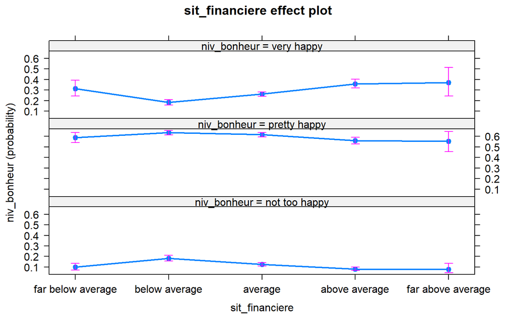

```r
# plot des effets
library(effects)
d_train$sit_financiere <- factor(d_train$sit_financiere, levels = c("far below average", "below average", "average", "above average", "far above average"))
plot(Effect(focal.predictors = "sit_financiere", reg_model))
```

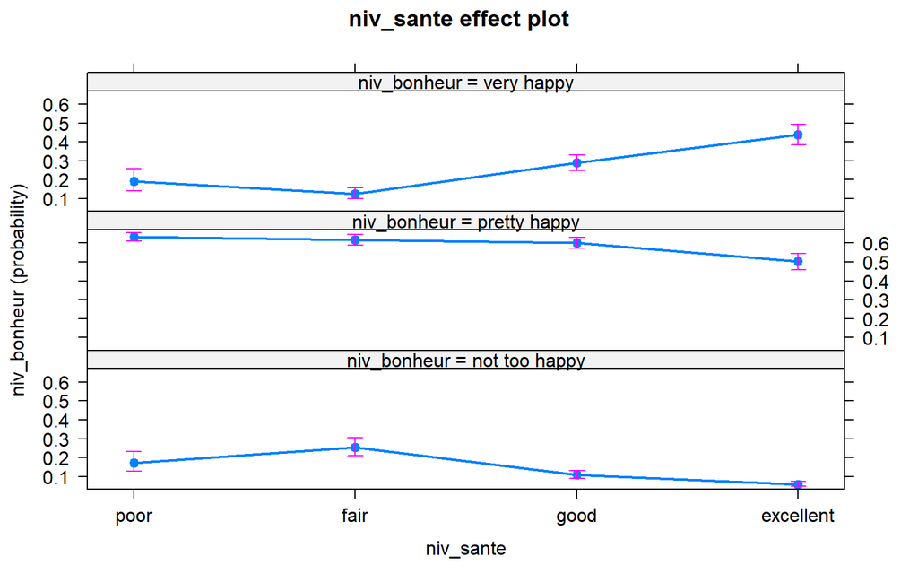

```r
d_train$niv_sante <- factor(d_train$niv_sante, levels = c("poor", "fair", "good", "excellent"))
plot(Effect(focal.predictors = "niv_sante", reg_model))
```

## 3.4 Evaluation du modèle

**Matrice de confusion :**

```r
predict_niv_bonheur <- predict(reg_model, d_test)
table(d_test$niv_bonheur, predict_niv_bonheur)
```

```
##                predict_niv_bonheur
##                 not too happy pretty happy very happy
##   not too happy             3          166         11
##   pretty happy              3          649        102
##   very happy                2          303        136
```

```r
mean(as.character(d_test$niv_bonheur) == as.character(predict_niv_bonheur), na.rm = TRUE)
```

```
## [1] 0.5730909
```